# Source memory performance for objects outside the rooms

# 1 Visual inspection of the data

# 2 Novelty Benefits

## 2.1 Check the data

**Is there any corrected hit rate < 0?**

There are 35 negative value out of a total of 80 values.

## 2.2 Compare mean accuracy between *novel* and *familiar* rooms

## 2.3 Any difference between *Early* and *Later* object groups?

### 2.3.1 Check the data

**Is there any corrected hit rate < 0?**

There are 35 negative value out of a total of 160 values.

### 2.3.2 Analysis

# 3 Curiosity Enhancement

## 3.1 Check the data

### 3.1.1 Is there any corrected hit rate < 0?

#### 3.1.1.1 For the data per room

- There are 35 negative values out of a total of 239 values.

#### 3.1.1.2 For the data per curiosity group

- There are 35 negative value for curiosity group (1 ~ 3 and 5 ~ 7) out of a total of 78 values.

#### 3.1.1.3 For the data per curiosity group (median)

- There are 35 negative value for curiosity group (median) out of a total of 79 values.

## 3.2 Mean accuracy of item memory as a function of curiosity rating

## 3.3 Testing the relationship between mean accuracy of item memory and curiosity rating

Build models with item memory accuracy as $y$ and examine effects of curiosity rating by including it into the model and then comparing the model fits.

- `baseline.rating` is the model with only an intercept, showing no change in item memory as a function of curiosity rating.
- `rating.intercept` is the model with $\small CuriosityRating$ included, showing the effects of curiosity rating.
- `rating.slope` is the model allowing the slope (i.e., relationship between item memory and curiosity rating) varying across participants.

## 3.4 Check the curiosity groups

### 3.4.1 Separate the groups according to the rating

- *High*: curiosity rating > 4
- *Low*: curiosity rating < 4
- For curiosity rating = 4, discarded

#### 3.4.1.1 Curiosity groups and temporal order of the objects

##### 3.4.1.1.1 *Post hoc*

### 3.4.2 Separate the groups according to the median rating of each participant

- *High*: curiosity rating > median of the participant
- *Low*: curiosity rating < median of the participant

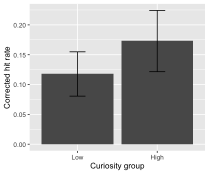

```
Linear mixed-effects model fit by maximum likelihood
 Data: outside.hit.rate.curiosity.group.median
```

|  | AIC | BIC | logLik |
| --- | --- | --- | --- |
|  | -87.5526 | -73.33591 | 49.7763 |

```
Random effects:
 Formula: ~1 + CurGrp | SubjectNo
 Structure: General positive-definite, Log-Cholesky parametrization
            StdDev     Corr
(Intercept) 0.10680190 (Intr)
CurGrpHigh  0.12555987 -0.137
Residual    0.05171143

Fixed effects: SrcAcc ~ CurGrp
```

|  | Value | Std.Error | DF | t-value | p-value |
| --- | --- | --- | --- | --- | --- |
| (Intercept) | 0.1180556 | 0.01900424 | 39 | 6.212063 | 0.0000 |
| CurGrpHigh | 0.0560965 | 0.02354738 | 38 | 2.382282 | 0.0223 |

```
 Correlation:
           (Intr)
CurGrpHigh -0.259

Standardized Within-Group Residuals:
         Min           Q1          Med           Q3          Max
-1.148166422 -0.282563070  0.005715828  0.256239147  1.180012342

Number of Observations: 79
Number of Groups: 40
```

#### 3.4.2.1 Curiosity groups and temporal order of the objects

##### 3.4.2.1.1 Check the data

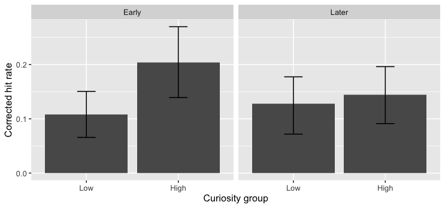

| CurGrpMedian | ObjOrdGrp | Mean | SD | N |
| --- | --- | --- | --- | --- |
| Low | Early | 0.1083333 | 0.1464498 | 40 |
| Low | Later | 0.1277778 | 0.1705416 | 40 |
| High | Early | 0.2037037 | 0.2071741 | 39 |
| High | Later | 0.1438746 | 0.1773418 | 39 |

|  | Model | df | AIC | BIC | logLik | Test | L.Ratio | p-value |
| --- | --- | --- | --- | --- | --- | --- | --- | --- |
| baseline | 1 | 8 | -106.7578 | -82.25702 | 61.37889 |  |  |  |
| ord.model | 2 | 9 | -104.7875 | -77.22411 | 61.39373 | 1 vs 2 | 0.029688 | 0.8632 |
| cur.model | 3 | 10 | -107.8327 | -77.20670 | 63.91632 | 2 vs 3 | 5.045178 | 0.0247 |
| int.model | 4 | 11 | -109.3756 | -75.68709 | 65.68782 | 3 vs 4 | 3.542993 | 0.0598 |

```
Linear mixed-effects model fit by maximum likelihood
 Data: outside.hit.rate.item.order.curiosity.median[!is.na(CurGrpMedian)]
```

|  | AIC | BIC | logLik |
| --- | --- | --- | --- |
|  | -109.3756 | -75.68709 | 65.68782 |

```
Random effects:
 Formula: ~1 + CurGrpMedian + ObjOrdGrp | SubjectNo
 Structure: General positive-definite, Log-Cholesky parametrization
                 StdDev     Corr
(Intercept)      0.09177459 (Intr) CrGrMH
CurGrpMedianHigh 0.07520889  0.822
ObjOrdGrpLater   0.09752662 -0.502 -0.667
Residual         0.12526359

Fixed effects: SrcAcc ~ ObjOrdGrp + CurGrpMedian + ObjOrdGrp:CurGrpMedian
```

|  | Value | Std.Error | DF | t-value | p-value |
| --- | --- | --- | --- | --- | --- |
| (Intercept) | 0.10833333 | 0.02486959 | 115 | 4.356056 | 0.0000 |
| ObjOrdGrpLater | 0.01944444 | 0.03238655 | 115 | 0.600386 | 0.5494 |
| CurGrpMedianHigh | 0.09284743 | 0.03116843 | 115 | 2.978894 | 0.0035 |
| ObjOrdGrpLater:CurGrpMedianHigh | -0.07640105 | 0.04043872 | 115 | -1.889304 | 0.0614 |

```
 Correlation:
                                (Intr) ObjOGL CrGrMH
ObjOrdGrpLater                  -0.643
CurGrpMedianHigh                -0.331  0.274
ObjOrdGrpLater:CurGrpMedianHigh  0.400 -0.615 -0.651

Standardized Within-Group Residuals:
       Min         Q1        Med         Q3        Max
-2.0069336 -0.5523128 -0.1014983  0.6154627  2.2125304

Number of Observations: 158
Number of Groups: 40
```

##### 3.4.2.1.2 *Post hoc*

```
     Simultaneous Tests for General Linear Hypotheses

Fit: lme.formula(fixed = SrcAcc ~ ObjOrdGrp + CurGrpMedian + ObjOrdGrp:CurGrpMedian,
    data = outside.hit.rate.item.order.curiosity.median[!is.na(CurGrpMedian)],
    random = ~1 + CurGrpMedian + ObjOrdGrp | SubjectNo, method = "ML",
    na.action = na.exclude, control = list(msMaxIter = 500, opt = "optim",
        msVerbose = FALSE))

Linear Hypotheses:
                         Estimate Std. Error z value Pr(>|z|)
Early: High vs. Low == 0  0.09285    0.03077   3.017  0.00255 **
Late:  High vs. Low == 0  0.01645    0.03069   0.536  0.59209
---
Signif. codes:  0 ‘***’ 0.001 ‘**’ 0.01 ‘*’ 0.05 ‘.’ 0.1 ‘ ’ 1
(Adjusted p values reported -- none method)
```